# Q1_HW4

Chao Huang

11/29/2019

## Exercise 1

```r
data <- read.csv("cigarettes.txt", header = T, sep = " ")
```

### 1. Dist. of response

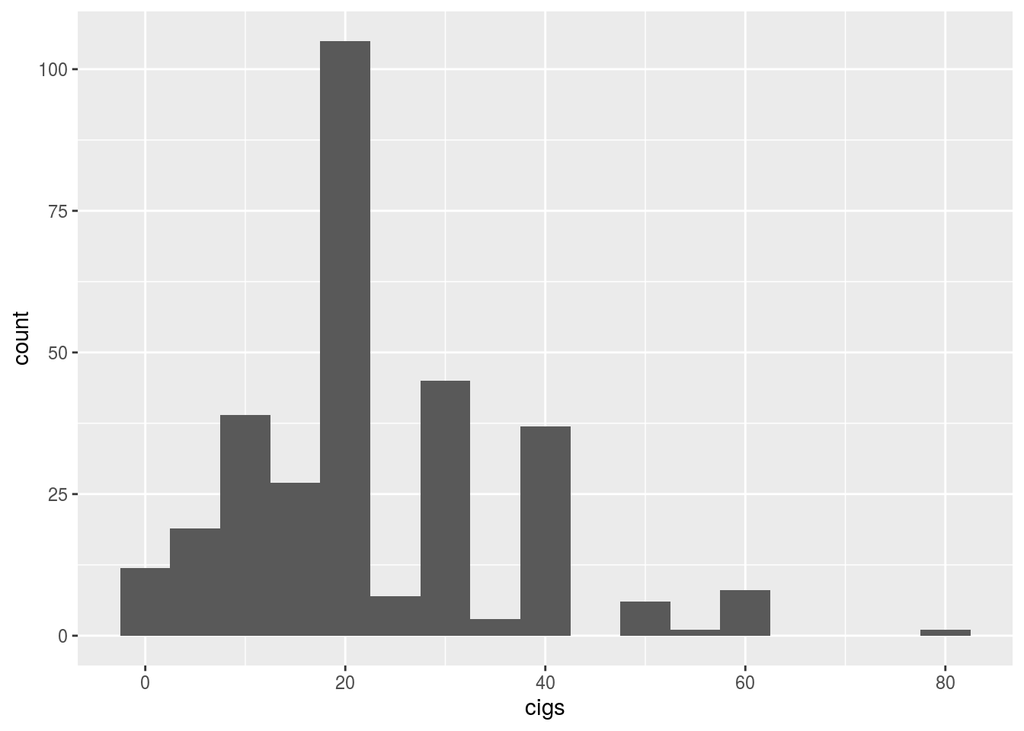

```r
ggplot(data, aes(x=cigs)) + geom_histogram(binwidth = 5)
```

The response variable has right-skewed distribution with multiple peaks. Numbers which are times of 10 have higher frequency than others and there are gaps between peaks. The rounding effect may come from the fact that people tend to consume a whole pack or half pack of cigarettes every day.

### 2. Fit a GAM

```r
library(mgcv)
model <- gam(cigs ~ educ + s(cigpric) + white + s(age) + s(income) + restaurn, data = data, family = poisson)
summary(model)
```

```
##
## Family: poisson
## Link function: log
##
## Formula:
## cigs ~ educ + s(cigpric) + white + s(age) + s(income) + restaurn
##
## Parametric coefficients:
##              Estimate Std. Error z value Pr(>|z|)
## (Intercept)  2.756222   0.072504  38.015  < 2e-16 ***
## educ         0.026496   0.005016   5.282 1.27e-07 ***
## white        0.046068   0.039448   1.168 0.242880
## restaurn    -0.126067   0.035152  -3.586 0.000335 ***
## ---
## Signif. codes:  0 '***' 0.001 '**' 0.01 '*' 0.05 '.' 0.1 ' ' 1
##
## Approximate significance of smooth terms:
##              edf Ref.df Chi.sq  p-value
## s(cigpric) 8.724  8.976  86.70 9.70e-15 ***
## s(age)     4.568  5.630 146.24  < 2e-16 ***
## s(income)  8.688  8.953  63.81 2.75e-10 ***
## ---
## Signif. codes:  0 '***' 0.001 '**' 0.01 '*' 0.05 '.' 0.1 ' ' 1
##
## R-sq.(adj) =  0.0993   Deviance explained = 16.9%
## UBRE = 5.6248  Scale est. = 1         n = 310
```

I would keep educ, white and restaurn in the parametric part since these covariates have fewer combination than the degree of freedom from the default setting of smooth function. For other covariates, using a smooth function will help increase deviance explained, so I add the smooth function for all of them.

### 3. Interpret overall effect of age

```r
cor(data$age, data$cigs)
```

```
## [1] 0.1153302
```

The age is positively correlated with the number of cigerattes smoked per day since the correlation is positive. Also it’s significant in the glm model using poisson distribution as the results above show.

### 4. Income in a linear fashion?

Model directly using income in a linear fashion

```r
model <- gam(cigs ~ educ + s(cigpric) + white + s(age) + (income) + restaurn, data = data, family = poisson)
summary(model)
```

```
##
## Family: poisson
## Link function: log
##
## Formula:
## cigs ~ educ + s(cigpric) + white + s(age) + (income) + restaurn
##
## Parametric coefficients:
##               Estimate Std. Error z value Pr(>|z|)
## (Intercept)  2.706e+00  7.138e-02  37.914  < 2e-16 ***
## educ         2.412e-02  4.946e-03   4.877 1.08e-06 ***
## white        4.097e-03  3.808e-02   0.108 0.914318
## income       6.177e-06  1.489e-06   4.148 3.35e-05 ***
## restaurn    -1.226e-01  3.497e-02  -3.506 0.000455 ***
## ---
## Signif. codes:  0 '***' 0.001 '**' 0.01 '*' 0.05 '.' 0.1 ' ' 1
##
## Approximate significance of smooth terms:
##              edf Ref.df Chi.sq  p-value
## s(cigpric) 8.747  8.980  91.73 5.98e-16 ***
## s(age)     4.412  5.458 146.53  < 2e-16 ***
## ---
## Signif. codes:  0 '***' 0.001 '**' 0.01 '*' 0.05 '.' 0.1 ' ' 1
##
## R-sq.(adj) =  0.099   Deviance explained = 14.7%
## UBRE = 5.7438  Scale est. = 1         n = 310
```

```r
AIC(model)
```

```
## [1] 3561.148
```

Model using income after a log transformation

```r
model <- gam(cigs ~ educ + s(cigpric) + white + s(age) + log(income) + restaurn, data = data, family = poisson())
summary(model)
```

```
##
## Family: poisson
## Link function: log
##
## Formula:
## cigs ~ educ + s(cigpric) + white + s(age) + log(income) + restaurn
##
## Parametric coefficients:
##              Estimate Std. Error z value Pr(>|z|)
## (Intercept)  1.817763   0.205350   8.852  < 2e-16 ***
## educ         0.023530   0.004937   4.766 1.88e-06 ***
## white        0.005823   0.038067   0.153 0.878431
## log(income)  0.104519   0.021057   4.964 6.92e-07 ***
## restaurn    -0.126965   0.035001  -3.627 0.000286 ***
## ---
## Signif. codes:  0 '***' 0.001 '**' 0.01 '*' 0.05 '.' 0.1 ' ' 1
##
## Approximate significance of smooth terms:
##              edf Ref.df Chi.sq  p-value
## s(cigpric) 8.759  8.982  91.98 5.35e-16 ***
## s(age)     4.296  5.322 141.29  < 2e-16 ***
## ---
## Signif. codes:  0 '***' 0.001 '**' 0.01 '*' 0.05 '.' 0.1 ' ' 1
##
## R-sq.(adj) =  0.102   Deviance explained =   15%
## UBRE = 5.7185  Scale est. = 1         n = 310
```

```r
AIC(model)
```

```
## [1] 3553.311
```

So Using a log transformation can help slightly decrease AIC if we want to include the income variable in the parametric part.

```r
model_wo_price <- gam(cigs ~ educ + s(cigpric) + white + s(age) + restaurn, data = data, family = poisson)

test <- anova.gam(model_wo_price, model, test = "LRT")
print(test)
```

```
## Analysis of Deviance Table
##
## Model 1: cigs ~ educ + s(cigpric) + white + s(age) + restaurn
## Model 2: cigs ~ educ + s(cigpric) + white + s(age) + log(income) + restaurn
##   Resid. Df Resid. Dev      Df Deviance  Pr(>Chi)
## 1    290.98     2070.7
## 2    290.70     2046.6 0.28191   24.066 9.906e-08 ***
## ---
## Signif. codes:  0 '***' 0.001 '**' 0.01 '*' 0.05 '.' 0.1 ' ' 1
```